# Risk Factor Analysis

## Outcome Variable

**Outcome Variable:** haz

## Predictor Variables

**Intervention Variable:** brthmon

**Adjustment Set:**

unadjusted

## Stratifying Variables

The analysis was stratified on these variable(s):

- agecat

## Data Summary

| agecat | brthmon | n_cell | n |
| --- | --- | --- | --- |
| Birth | 1 | 4437 | 52031 |
| Birth | 2 | 3881 | 52031 |
| Birth | 3 | 4508 | 52031 |
| Birth | 4 | 3724 | 52031 |
| Birth | 5 | 3328 | 52031 |
| Birth | 6 | 3490 | 52031 |
| Birth | 7 | 3880 | 52031 |
| Birth | 8 | 4421 | 52031 |
| Birth | 9 | 4847 | 52031 |
| Birth | 10 | 5081 | 52031 |
| Birth | 11 | 5098 | 52031 |
| Birth | 12 | 5336 | 52031 |
| 6 months | 1 | 4251 | 58900 |
| 6 months | 2 | 4233 | 58900 |
| 6 months | 3 | 5181 | 58900 |
| 6 months | 4 | 4494 | 58900 |
| 6 months | 5 | 4313 | 58900 |
| 6 months | 6 | 4346 | 58900 |
| 6 months | 7 | 5039 | 58900 |
| 6 months | 8 | 5617 | 58900 |
| 6 months | 9 | 5445 | 58900 |
| 6 months | 10 | 5374 | 58900 |
| 6 months | 11 | 5297 | 58900 |
| 6 months | 12 | 5310 | 58900 |
| 24 months | 1 | 1537 | 24770 |
| 24 months | 2 | 2155 | 24770 |
| 24 months | 3 | 2500 | 24770 |
| 24 months | 4 | 2011 | 24770 |
| 24 months | 5 | 1750 | 24770 |
| 24 months | 6 | 1847 | 24770 |
| 24 months | 7 | 2253 | 24770 |
| 24 months | 8 | 2243 | 24770 |
| 24 months | 9 | 2132 | 24770 |
| 24 months | 10 | 2045 | 24770 |
| 24 months | 11 | 2027 | 24770 |
| 24 months | 12 | 2270 | 24770 |

The following strata were considered:

- agecat: 24 months
- agecat: 6 months
- agecat: Birth

## Methods Detail

We’re interested in the causal parameters $E[Y_a]$ for all values of $a \in \mathcal{A}$. These parameters represent the mean outcome if, possibly contrary to fact, we intervened to set all units to have $A=a$. Under the randomization and positivity assumptions, these are identified by the statistical parameters $\psi_a=E_W[E_{Y|A,W}(Y|A=a,W)]$. In addition, we’re interested in the mean of $Y$, $E[Y]$ under no intervention (the observed mean). We will estimate these parameters by using SuperLearner to fit the relevant likelihood factors – $E_{Y|A,W}(Y|A=a,W)$ and $p(A=a|W)$, and then updating our likelihood fit using a joint TMLE.

For unadjusted analyses ($W=\{\}$), initial likelihoods were estimated using Lrnr_glm to estimate the simple $E(Y|A)$ and Lrnr_mean to estimate $p(A)$. For adjusted analyses, a small library containing Lrnr_glmnet, Lrnr_xgboost, and Lrnr_mean was used.

Having estimated these parameters, we will then use the delta method to estimate relative risks and attributable risks relative to a prespecified baseline level of $A$.

# Results Detail

## Results Plots

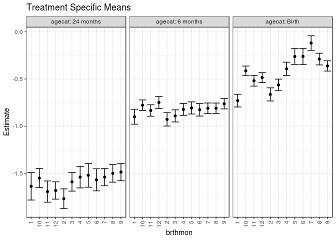

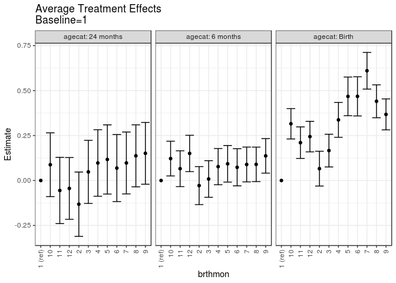

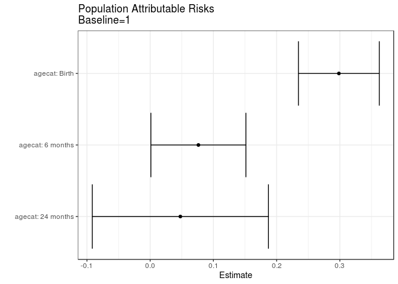

## Results Table

### Parameter: TSM

| agecat | intervention_level | baseline_level | estimate | ci_lower | ci_upper |
| --- | --- | --- | --- | --- | --- |
| Birth | 1 | NA | -0.7292044 | -0.7964337 | -0.6619751 |
| Birth | 2 | NA | -0.6632234 | -0.7328710 | -0.5935758 |
| Birth | 3 | NA | -0.5628594 | -0.6244101 | -0.5013086 |
| Birth | 4 | NA | -0.3919603 | -0.4621310 | -0.3217895 |
| Birth | 5 | NA | -0.2613011 | -0.3455020 | -0.1771002 |
| Birth | 6 | NA | -0.2611662 | -0.3467975 | -0.1755349 |
| Birth | 7 | NA | -0.1188582 | -0.1956890 | -0.0420275 |
| Birth | 8 | NA | -0.2886406 | -0.3507913 | -0.2264898 |
| Birth | 9 | NA | -0.3614689 | -0.4156514 | -0.3072865 |
| Birth | 10 | NA | -0.4137414 | -0.4648689 | -0.3626138 |
| Birth | 11 | NA | -0.5187348 | -0.5750099 | -0.4624597 |
| Birth | 12 | NA | -0.4850262 | -0.5370975 | -0.4329550 |
| 6 months | 1 | NA | -0.8995062 | -0.9784660 | -0.8205465 |
| 6 months | 2 | NA | -0.9277939 | -0.9981690 | -0.8574187 |
| 6 months | 3 | NA | -0.8910179 | -0.9552897 | -0.8267462 |
| 6 months | 4 | NA | -0.8223471 | -0.8850938 | -0.7596005 |
| 6 months | 5 | NA | -0.8065672 | -0.8707948 | -0.7423396 |
| 6 months | 6 | NA | -0.8260611 | -0.8928469 | -0.7592752 |
| 6 months | 7 | NA | -0.8103525 | -0.8663918 | -0.7543131 |
| 6 months | 8 | NA | -0.8096677 | -0.8643674 | -0.7549680 |
| 6 months | 9 | NA | -0.7624281 | -0.8171600 | -0.7076963 |
| 6 months | 10 | NA | -0.7775409 | -0.8332988 | -0.7217831 |
| 6 months | 11 | NA | -0.8338396 | -0.8943807 | -0.7732986 |
| 6 months | 12 | NA | -0.7488904 | -0.8118917 | -0.6858892 |
| 24 months | 1 | NA | -1.6375038 | -1.7826610 | -1.4923466 |
| 24 months | 2 | NA | -1.7691124 | -1.8734691 | -1.6647556 |
| 24 months | 3 | NA | -1.5895867 | -1.6880619 | -1.4911115 |
| 24 months | 4 | NA | -1.5400273 | -1.6542357 | -1.4258190 |
| 24 months | 5 | NA | -1.5204288 | -1.6466215 | -1.3942360 |
| 24 months | 6 | NA | -1.5683007 | -1.6851590 | -1.4514423 |
| 24 months | 7 | NA | -1.5399373 | -1.6314743 | -1.4484004 |
| 24 months | 8 | NA | -1.5001394 | -1.5931500 | -1.4071288 |
| 24 months | 9 | NA | -1.4862921 | -1.5785762 | -1.3940080 |
| 24 months | 10 | NA | -1.5497632 | -1.6511985 | -1.4483278 |
| 24 months | 11 | NA | -1.6928120 | -1.8051098 | -1.5805143 |
| 24 months | 12 | NA | -1.6814101 | -1.7728354 | -1.5899847 |

### Parameter: E(Y)

| agecat | intervention_level | baseline_level | estimate | ci_lower | ci_upper |
| --- | --- | --- | --- | --- | --- |
| Birth | NA | NA | -0.4307371 | -0.4495348 | -0.4119393 |
| 6 months | NA | NA | -0.8232017 | -0.8412659 | -0.8051376 |
| 24 months | NA | NA | -1.5897500 | -1.6199381 | -1.5595618 |

### Parameter: ATE

| agecat | intervention_level | baseline_level | estimate | ci_lower | ci_upper |
| --- | --- | --- | --- | --- | --- |
| Birth | 1 | 1 | 0.0000000 | 0.0000000 | 0.0000000 |
| Birth | 2 | 1 | 0.0659810 | -0.0307500 | 0.1627120 |
| Birth | 3 | 1 | 0.1663451 | 0.0752911 | 0.2573990 |
| Birth | 4 | 1 | 0.3372442 | 0.2402018 | 0.4342865 |
| Birth | 5 | 1 | 0.4679033 | 0.3602457 | 0.5755609 |
| Birth | 6 | 1 | 0.4680382 | 0.3591838 | 0.5768927 |
| Birth | 7 | 1 | 0.6103462 | 0.5083467 | 0.7123457 |
| Birth | 8 | 1 | 0.4405638 | 0.3490853 | 0.5320424 |
| Birth | 9 | 1 | 0.3677355 | 0.2814923 | 0.4539786 |
| Birth | 10 | 1 | 0.3154630 | 0.2311393 | 0.3997867 |
| Birth | 11 | 1 | 0.2104696 | 0.1229016 | 0.2980376 |
| Birth | 12 | 1 | 0.2441782 | 0.1592826 | 0.3290737 |
| 6 months | 1 | 1 | 0.0000000 | 0.0000000 | 0.0000000 |
| 6 months | 2 | 1 | -0.0282876 | -0.1339389 | 0.0773636 |
| 6 months | 3 | 1 | 0.0084883 | -0.0932552 | 0.1102318 |
| 6 months | 4 | 1 | 0.0771591 | -0.0236353 | 0.1779535 |
| 6 months | 5 | 1 | 0.0929390 | -0.0087843 | 0.1946623 |
| 6 months | 6 | 1 | 0.0734452 | -0.0298389 | 0.1767293 |
| 6 months | 7 | 1 | 0.0891538 | -0.0076329 | 0.1859405 |
| 6 months | 8 | 1 | 0.0898385 | -0.0061511 | 0.1858281 |
| 6 months | 9 | 1 | 0.1370781 | 0.0410529 | 0.2331034 |
| 6 months | 10 | 1 | 0.1219653 | 0.0253563 | 0.2185743 |
| 6 months | 11 | 1 | 0.0656666 | -0.0338599 | 0.1651931 |
| 6 months | 12 | 1 | 0.1506158 | 0.0496068 | 0.2516248 |
| 24 months | 1 | 1 | 0.0000000 | 0.0000000 | 0.0000000 |
| 24 months | 2 | 1 | -0.1316086 | -0.3105161 | 0.0472989 |
| 24 months | 3 | 1 | 0.0479171 | -0.1274987 | 0.2233329 |
| 24 months | 4 | 1 | 0.0974764 | -0.0875171 | 0.2824699 |
| 24 months | 5 | 1 | 0.1170750 | -0.0754682 | 0.3096182 |
| 24 months | 6 | 1 | 0.0692031 | -0.1172474 | 0.2556537 |
| 24 months | 7 | 1 | 0.0975665 | -0.0744965 | 0.2696294 |
| 24 months | 8 | 1 | 0.1373644 | -0.0350701 | 0.3097989 |
| 24 months | 9 | 1 | 0.1512117 | -0.0206699 | 0.3230932 |
| 24 months | 10 | 1 | 0.0877406 | -0.0895404 | 0.2650216 |
| 24 months | 11 | 1 | -0.0553082 | -0.2394916 | 0.1288751 |
| 24 months | 12 | 1 | -0.0439063 | -0.2157477 | 0.1279351 |

### Parameter: PAR

| agecat | intervention_level | baseline_level | estimate | ci_lower | ci_upper |
| --- | --- | --- | --- | --- | --- |
| Birth | 1 | NA | 0.2984674 | 0.2345113 | 0.3624234 |
| 6 months | 1 | NA | 0.0763045 | 0.0011386 | 0.1514704 |
| 24 months | 1 | NA | 0.0477538 | -0.0915864 | 0.1870941 |